# RNAseq analysis, hybrid necrosis project

Marta Binaghi

June 23, 2022

Last modified: June 23rd, 2022

# Setup

```r
library("DESeq2")
```

```r
library("ggplot2")
library("PoiClaClu")
library("pheatmap")
library("RColorBrewer")

workdir <- "/media/ipsnas/Groups/Deve/Current lab members/marta/necrosis_peaxiINV/"

knitr::opts_knit$set(root.dir = workdir)
knitr::opts_chunk$set(root.dir = workdir)
```

# Import read counts

```r
myCountsFile <- "data/raw/rs_counts/rs_counts.txt"
raw_counts <- read.table(myCountsFile,
                         header = T,
                         comment.char = "#",      # needed to remove first line of file
                         stringsAsFactors = F)
# set geneid as row names
rownames(raw_counts) <- raw_counts$Geneid
# remove not-needed columns, leave only the counts
raw_counts <- raw_counts[ , c(7:dim(raw_counts)[2])]

# rename columns with simpler and meaningful sample names
# extract original name "KMHX"
original_id <- gsub("(kmh\\d+)_trim_STAR.*",
                  "\\1",
                  colnames(raw_counts))
# add sample name
new_names <- rep("a", times = length(original_id))
new_names[grepl("(1|2|3)", original_id)] <- "ax-"
new_names[grepl("(4|5|6)", original_id)] <- "ex-"
new_names[grepl("(7|8|9)", original_id)] <- "het-"

# add replicate
new_names[grepl("(1|4|7)", original_id)] <- paste0(new_names[grepl("(1|4|7)", original_id)], "1")
new_names[grepl("(2|5|8)", original_id)] <- paste0(new_names[grepl("(2|5|8)", original_id)], "2")
new_names[grepl("(3|6|9)", original_id)] <- paste0(new_names[grepl("(3|6|9)", original_id)], "3")

colnames(raw_counts) <- new_names
rm(new_names, original_id)
```

# Make deseq datasets

```r
# make a dataframe containing the condition group of each sample
sampleGroup <- sub("([A-Za-z]+)-[1-3]", "\\1", colnames(raw_counts))
colData <- data.frame(condition = factor(sampleGroup))
# make DeSeq dataframe
dds_axexhet <- DESeqDataSetFromMatrix(raw_counts, colData, formula(~condition))
# run deseq
dds_axexhet <- DESeq(dds_axexhet)
# save non- and normalised counts
counts_raw <- counts(dds_axexhet,
                     normalized = FALSE)
counts_normalised <- counts(dds_axexhet,
                            normalized = TRUE)
```

# Exploratory analysis

Show read count per sample.

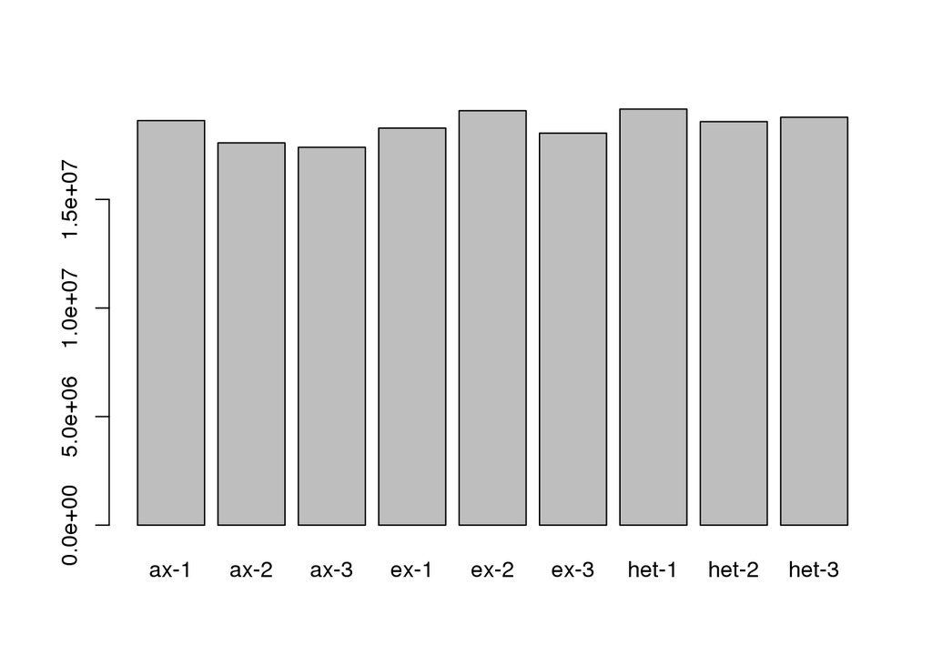

```r
# read count per sample
barplot(colSums(counts_raw))
```

Make a boxplot to show counts raw and normalised per sample per gene

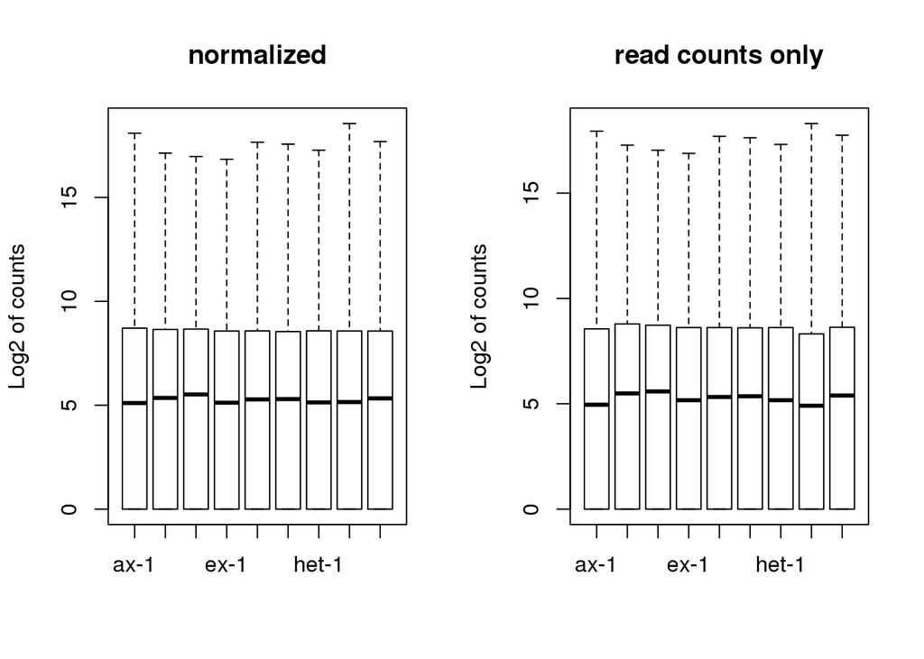

```r
## adding the boxplots
par(mfrow=c(1,2))
boxplot(log2(counts_normalised +1 ),
        ylab = "Log2 of counts",
        main = "normalized", cex = .6)
boxplot(log2(counts_raw + 1),
        ylab = "Log2 of counts",
        main = "read counts only", cex = .6)
```

```r
# apply a regularized log transformation, ignoring information about experimental groups
rld_axexhet <- rlog(dds_axexhet,
                    blind = TRUE)
# make the plot
p <- function(){plotPCA(rld_axexhet, intgroup = c("condition")) +
  ggtitle("PCA of rlog of 500 most variably expressed genes")
}
# save the plot in figures/rs/rs_plot_DE_PCA_500_axexhet.png
png("figures/rs/rs_plot_DE_PCA_500_axexhet.png")
p()
dev.off()
```

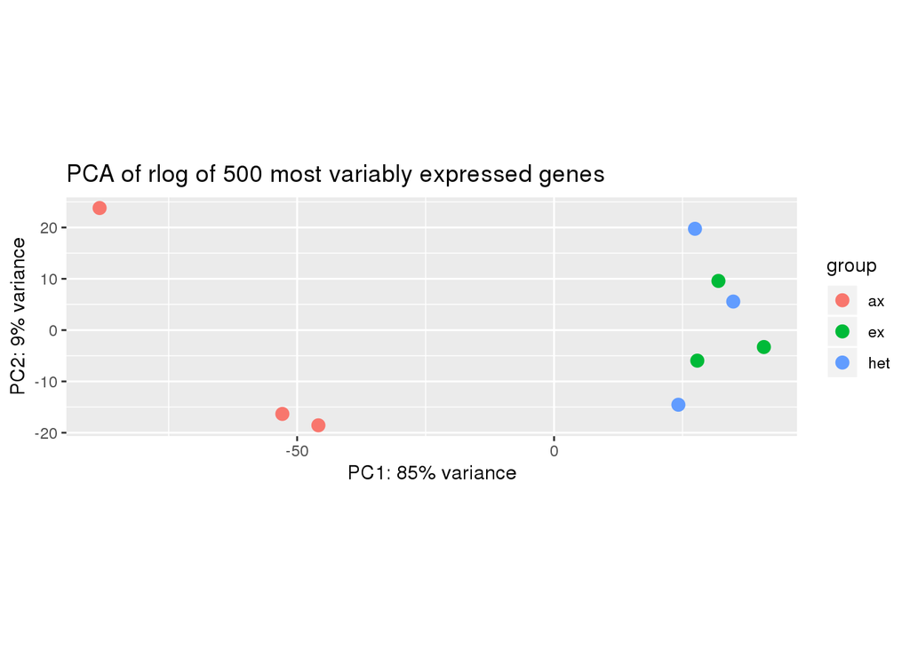

```r
p()
```

The plot shows that one biological replicate of the axillaris genotype is not clustering with the other 2. We therefore observe a heatmap of the transformed counts of the highest expressed genes, and then observe a Poisson distance matrix of the normalised counts to see if that sample is problematic.

```r
select <- order(rowMeans(counts_normalised),
                decreasing = TRUE)[1:20]
pl <- function(){pheatmap(assay(rld_axexhet)[select,],
         cluster_rows = FALSE, show_rownames = FALSE,
         cluster_cols = FALSE,
         main = "rlog transformed counts of 20 most highly expressed genes")
}
png("figures/rs/rs_plot_heatmap_rld_axexhet.png")
pl()
dev.off()
```

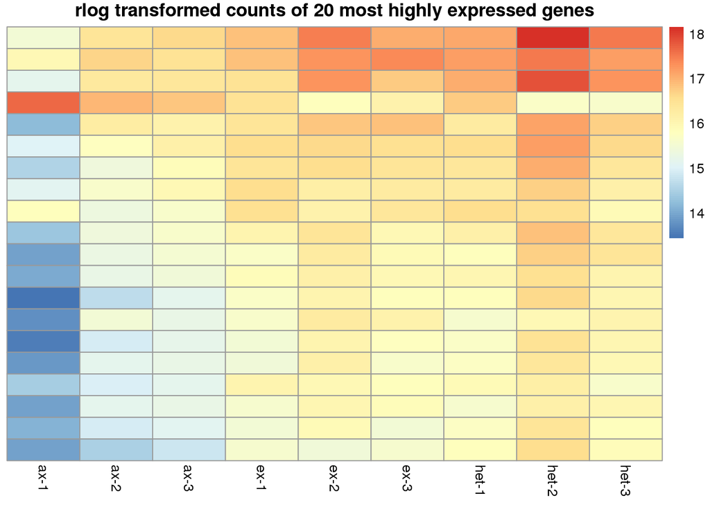

```r
pl()
```

```r
poisd <- PoissonDistance(t(counts_normalised))
samplePoisDistMatrix <- as.matrix( poisd$dd )
rownames(samplePoisDistMatrix) <- colnames(raw_counts)
colnames(samplePoisDistMatrix) <- colnames(raw_counts)

pl <- function() {pheatmap(samplePoisDistMatrix,
         clustering_distance_rows=poisd$dd,
         clustering_distance_cols=poisd$dd,
         main = "Heatmap of the Poisson distance between normalised counts of samples")
}
png("figures/rs/rs_plot_poisson_distance_heatmap_axexhet.png")
pl()
dev.off()
```

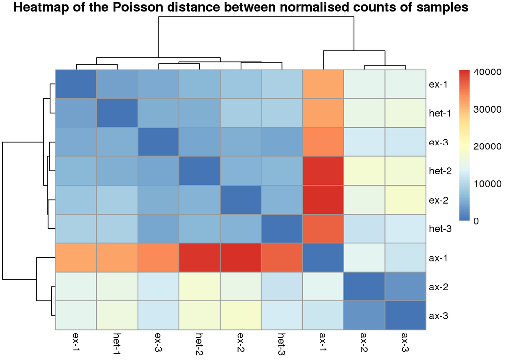

```r
pl()
```

We can see that the sample "ax-1" is really different from the others of the same genotype. We therefore exclude it from the analysis as it is an outlier.

# Re-do DESeq dataset without the outlier sample

Exclude the outlier biological replicate and run DESeq again.

```r
colData_clean <- data.frame(condition = colData[-1 , ])
# make DeSeq dataframe
raw_counts_clean <- raw_counts[ , colnames(raw_counts) != "ax-1"]
dds_clean <- DESeqDataSetFromMatrix(raw_counts_clean,
                                    colData_clean,
                                    formula(~condition))
# set reference level
dds_clean$condition <- relevel(dds_clean$condition, ref="ex")
# run deseq
dds_clean <- DESeq(dds_clean)
# extract non- and normalised counts
counts_clean_raw <- counts(dds_clean,
                     normalized = FALSE)
counts_clean_normalised <- counts(dds_clean,
                            normalized = TRUE)
```

We can now recalculate the distance matrix and show it as heatmap to check that the samples are homogeneous.

```r
poisd <- PoissonDistance(t(counts_clean_normalised))
samplePoisDistMatrix <- as.matrix( poisd$dd )
rownames(samplePoisDistMatrix) <- colnames(raw_counts_clean)
colnames(samplePoisDistMatrix) <- colnames(raw_counts_clean)

pl <- function() {pheatmap(samplePoisDistMatrix,
         clustering_distance_rows=poisd$dd,
         clustering_distance_cols=poisd$dd,
         main = "Heatmap of the Poisson distance between normalised counts of cleaned samples")
}
png("figures/rs/rs_plot_poisson_distance_heatmap_clean_samples_axexhet.png")
pl()
dev.off()
```

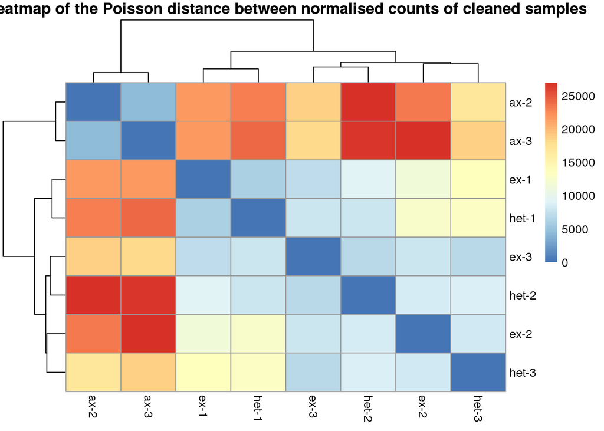

```r
pl()
```

Now we see that the samples across replicates are homogeneous.

We display the MA plot for the copmparison axillaris VS exserta and heterozygous VS exserta.

```r
# MA-plot of mean expression against log-fold change where axillaris is compared
# to exserta (ie log2 shows DE in axillaris compared to exserta)
# Genes with p-adjusted value < alpha will be shown in red.
res_clean_axex <- results(dds_clean,
                     contrast = c("condition", "ax", "ex"),
                     alpha = 0.05)
pl1 <- function(){plotMA(res_clean_axex,
       main = "Axillaris VS exserta")
}
png("figures/rs/rs_plot_DE_MA_axVSex.png")
pl1()
dev.off()
```

```r
# also compare heterozygous versus exserta
res_clean_hetex <- results(dds_clean,
                     contrast = c("condition", "het", "ex"),
                     alpha = 0.05)
pl2 <- function(){
  plotMA(res_clean_hetex,
       main = "Heterozygous VS exserta")
}
png("figures/rs/rs_plot_DE_MA_hetVSex.png")
pl2()
dev.off()
```

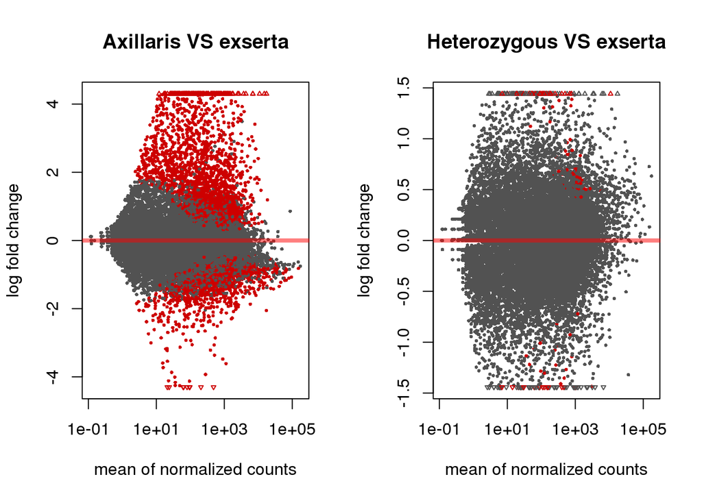

```r
par(mfrow=c(1,2))
pl1()
pl2()
```

We then export the raw, normalised counts and the DE data to a file.

```r
#raw counts
rawc <- counts_clean_raw
colnames(rawc) <- paste0("rawCounts_",
                         colnames(rawc))
# normalised counts
normc <- counts_clean_normalised
colnames(normc) <- paste0("normCounts_",
                         colnames(normc))

# DE comparing axillaris VS exserta
resDE <- as.data.frame(results(dds_clean,
                 contrast = c("condition", "ax", "ex")))
colnames(resDE) <- paste0("de_axVSex_",
                          colnames(resDE))
combined_results <- cbind(rawc,
                          normc,
                          resDE)
# save to table
write.csv(combined_results,
            "data/clean/rs_DE_results_axVSex.csv",
            quote = FALSE,
            row.names = TRUE)
```